# Course Notes 6

January 12, 2016

## Point maps

## Point maps

It is very easy now to create point maps in R based on longitude and latitude values of specific loacations.

You can use the `map_data` function from the `ggplot2` package to pull data for maps at different levels ("usa", "state", "world", "county").

## Point maps

The maps you pull using `map_data` are just the data to use for the polygon shapes (e.g., states, counties)– you will need to add on any data points yourself.

```r
library(ggplot2)
us_map <- map_data("state")
head(us_map, 3)
```

```
##        long      lat group order  region subregion
## 1 -87.46201 30.38968     1     1 alabama      <NA>
## 2 -87.48493 30.37249     1     2 alabama      <NA>
## 3 -87.52503 30.37249     1     3 alabama      <NA>
```

## Point maps

To plot the underlying map (of states, in this example), you can use `ggplot`. You need to specify that `x` is `long` and `y` is `lat`. You also need to specify that the `group` is `group`. This will plot the border of each state as a separate unit.

```r
map_1 <- ggplot(us_map, aes(x = long, y = lat, group = group)) +
        geom_polygon(fill = "dodgerblue", color = "white") +
        theme_void()
```

## Point maps

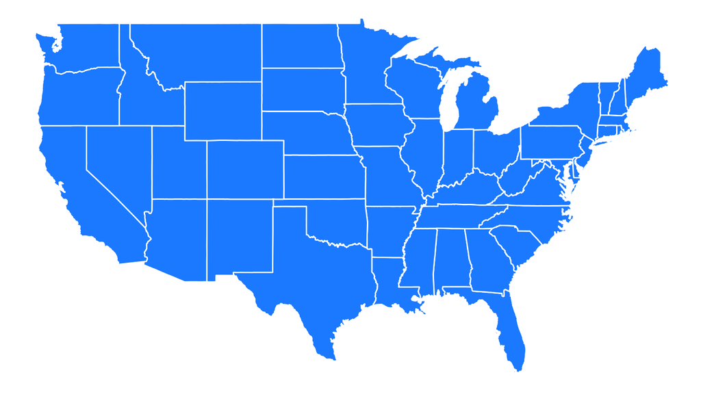

```r
map_1
```

## Point maps

You can use similar code to map China, using the "world" map and specifying that a region of "China". It is unclear, though, if this map has the data to do subregions of China.

```r
china_map <- map_data("world", region = "China")
map_2 <- ggplot(china_map, aes(x = long, y = lat, group = group)) +
        geom_polygon(fill = "dodgerblue", color = "white") +
        theme_bw()
```

## Point maps

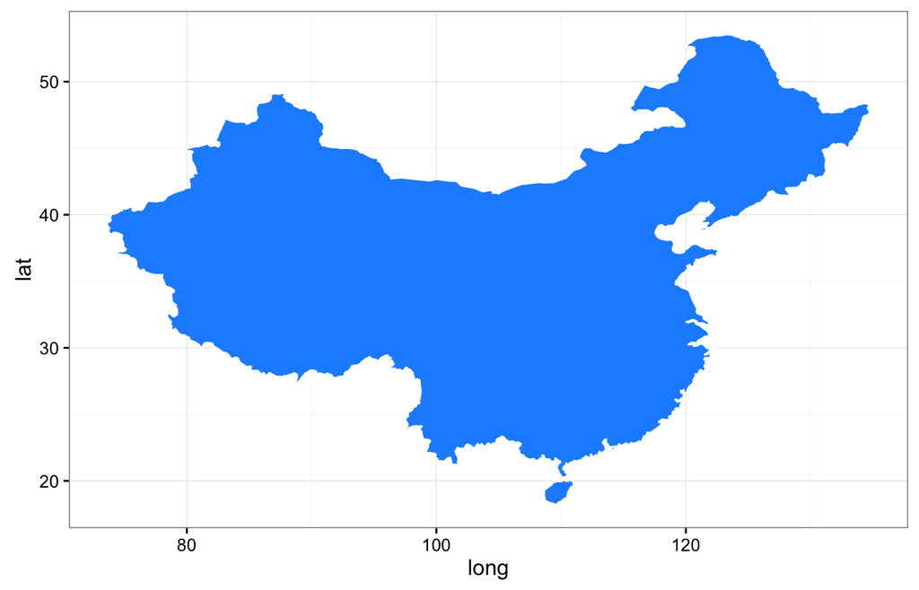

```r
map_2
```

## Point maps

To add points, you will need to have a dataset of points you want to plot, along with their latitudes and longitudes. Here I'll use an example of data points related to the story told in last year's ["Serial" podcast](http://serialpodcast.org).

```r
serial <- read.csv("data/serial_map_data.csv")
head(serial, 3)
```

```
##     x   y      Type Name Description
## 1 356 437 cell-site L688
## 2 740 360 cell-site L698
## 3 910 340 cell-site L654
```

## Point maps

[Someone on GitHub](https://github.com/dgrtwo/serial-ggvis/blob/master/serial-preprocessing.Rmd) figured out a way to convert the x and y coordinates in this data to latitude and longitude coordinates. I'm also adding a column for whether of not the point is a cell tower.

```r
library(dplyr)
serial <- serial %>%
    mutate(long = -76.8854 + 0.00017022 * x,
           lat  = 39.23822 + 1.371014e-04 * y,
           tower = Type == "cell-site")
```

## Point maps

```r
serial[c(1:2, (nrow(serial) - 1):nrow(serial)), ]
```

```
##      x   y          Type          Name Description      long      lat
## 1  356 437     cell-site          L688             -76.82480 39.29813
## 2  740 360     cell-site          L698             -76.75944 39.28758
## 24 720 496 base-location Adnan's house             -76.76284 39.30622
## 25 954 410 base-location  Jenn's house             -76.72301 39.29443
##    tower
## 1   TRUE
## 2   TRUE
## 24 FALSE
## 25 FALSE
```

## Point maps

Now I can map just Baltimore City and Baltimore County in Maryland and add these points.

I grabbed the "county" map and specified that the "region" was "maryland", to limit the map just to Maryland counties.

```r
baltimore <- map_data('county', region = 'maryland')
head(baltimore, 3)
```

```
##        long      lat group order   region subregion
## 1 -78.64992 39.53982     1     1 maryland  allegany
## 2 -78.70148 39.55128     1     2 maryland  allegany
## 3 -78.74159 39.57420     1     3 maryland  allegany
```

## Point maps

From that, I subsetted out just rows where the `subregion` column was "baltimore city" or "baltimore".

```r
baltimore <- subset(baltimore,
                    subregion %in% c("baltimore city", "baltimore"))
head(baltimore, 3)
```

```
##          long      lat group order   region subregion
## 114 -76.88521 39.35074     3   114 maryland baltimore
## 115 -76.89094 39.37939     3   115 maryland baltimore
## 116 -76.88521 39.40804     3   116 maryland baltimore
```

## Point maps

I used `geom_point` to my points. `ggplot` uses the `group` column to group together counties, but we don't need that in the points, so I needed to set `group = NA` in the `geom_point` statement. I put `color = tower` inside the `aes` statement so that the points would be one color for cell towers and another color for everything else.

```r
balt_plot <- ggplot(baltimore, aes(x = long, y = lat, group = group)) +
        geom_polygon(fill = "lightblue", color = "black") +
        geom_point(data = serial, aes(x = long, y = lat,
                                      group = NA, color = tower)) +
        theme_bw()
```

## Point maps

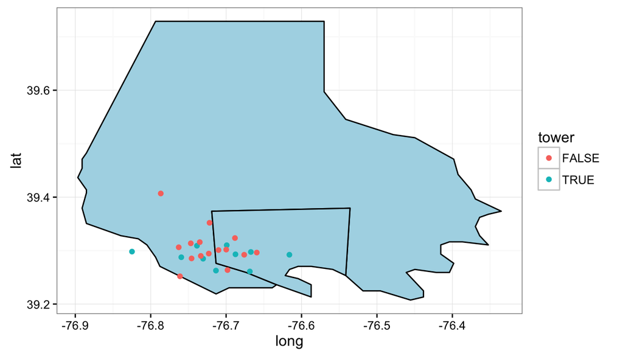

```r
balt_plot
```

## Choropleths in R

## Choropleths in R

There's a fantastic new(-ish) package in R to plot choropleth maps. You could also plot choropleths using `ggplot` and other mapping functions, but I would strongly recommend this new package if you're mapping the US.

You will need to install and load the `choroplethr` package in R to use the functions below.

```r
# install.packages("choroplethr")
library(choroplethr)

# install.packages("choroplethrMaps")
library(choroplethrMaps)
```

## Choropleths in R

At the most basic level, you can use this package to plot some data that comes automatically with the package (you'll just need to load the data using the `data` function). For example, if you wanted to plot state-by-state populations as of 2012, you could use:

```r
data(df_pop_state)
map_3 <- state_choropleth(df_pop_state)
```

## Choropleths in R

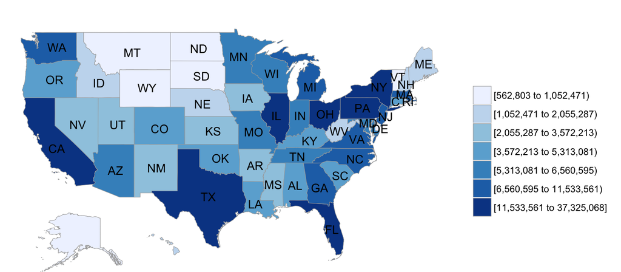

```r
map_3
```

## Choropleths in R

You can find out more about the `df_pop_state` data if you type `?df_pop_state`. Notice that, for the dataframe, the location is given in a column called `region` and the population size to plot is in a column called `value`.

```r
head(df_pop_state, 3)
```

```
##    region   value
## 1 alabama 4777326
## 2  alaska  711139
## 3 arizona 6410979
```

## Choropleths in R

You could use this function to create any state-level choropleth you wanted, as long as you could create a dataframe with a column for states called `region` and a column with the value you want to show called `value`.

## Choropleths in R

You can run similar functions at different spatial resolutions (for example, county or zip code):

```r
data(df_pop_county)
head(df_pop_county, 3)
```

```
##   region  value
## 1   1001  54590
## 2   1003 183226
## 3   1005  27469
```

## Choropleths in R

You can plot choropleths at this level, as well:

```r
map_4 <- county_choropleth(df_pop_county)
```

## Choropleths in R

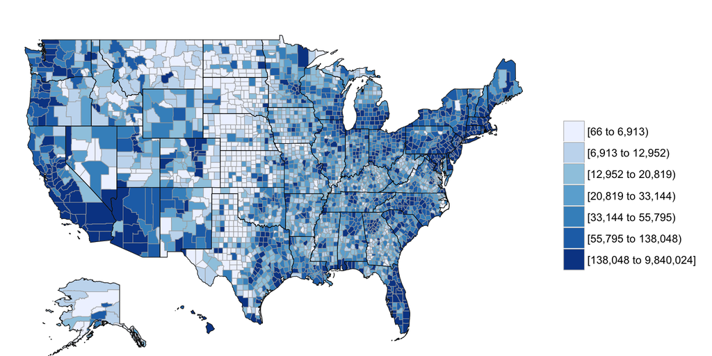

```r
map_4
```

## Choropleths in R

You can even do this for countries of the world:

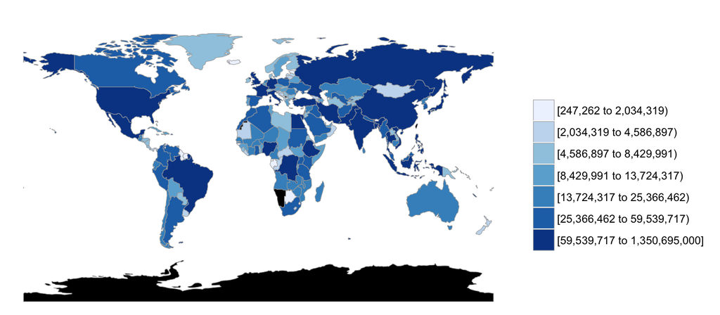

```r
data(df_pop_country)
country_choropleth(df_pop_country)
```

## Choropleths in R

You can even zoom to states or counties. For example, to plot population by county in Colorado, you could run:

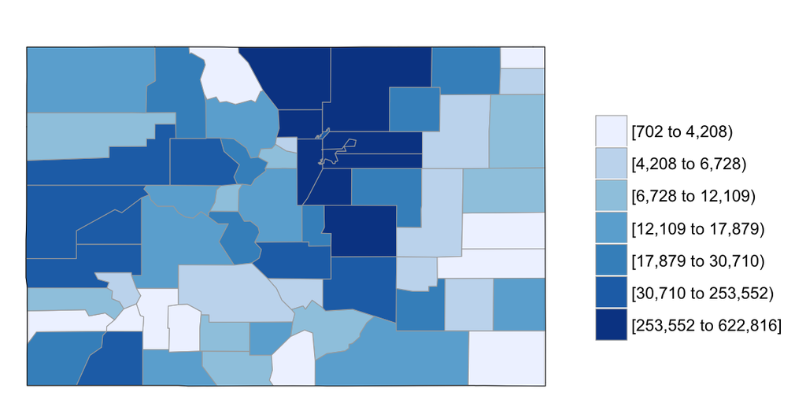

```r
county_choropleth(df_pop_county, zoom = "colorado")
```

## Other mapping resources

There is a lot more you can do with mapping and spatial statistics in R, but it gets much more complex once you start using shapefiles, etc.

Other resources for mapping and spatial statistics in R include:

- [CRAN's list of packages for spatial statistics](https://cran.r-project.org/web/views/Spatial.html)
- "Applied Spatial Data Analysis with R" by Bivand et al.– excellent book with a lot of R code examples
- [R Spatial Tips website](http://spatial.ly/r/)